# HW3Questions

Kari Theobald

1/26/2019

## **Question 1**

### GitHub Cloning : Using Git, clone the following GitHub repository to your local machine: https://github.com/caesar0301/awesome-public-datasets. In RMarkdown, please show the code (commented out, as it’s not R syntax) that you used to create a new directory, navigate to the appropriate directory, and clone the repository to it. One Git command per line, please.

Change the working directory (Unix) : $cd /desktop/kari/SMU*/Doing*Data*Science

Make a working directoy : $mkdir Repository

Change working directory to Repository : $cd Repository

Clone the repository from the given Github website and store on the local machine. : $git clone https://github.com/caesar0301/awesome-public-datasets

## **Question 2**

### Data Summary: From this aforementioned cloned repo, please extract titanic.csv.zip. To be clear, this does not have to be done in Git or command line.

1. In R, please read in titanic.csv via either read.table() or read.csv(), assigning it to df. This dataset follows the passengers aboard the Titanic, including their fees paid, rooms rented, and survivorship status.

```r
# Add readr package so we can read in a .cvs file on the local computer.
library(readr)

# Set the working directory in R studio to the folder wher the file is held.
setwd("~/Desktop/Kari/SMU /Doing Data Science/Repository/awesome-public-datasets/Datasets")

# Assign df the contents with the .csv file.
df<- read.csv("titanic.csv", sep=',', header=TRUE)  #assign df the titantic.csv file
```

2. Output the respective count of females and males aboard the Titanic. Plot the frequency of females and males. Be sure to give an accurate title and label the axes.

```r
table(df$Sex)  #Display how many males and females are in df
```

```
##
## female   male
##    314    577
```

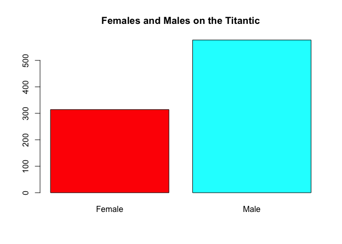

```r
gender<-table(df$Sex) #Assign Gender the specific column Sex in the df table.
barplot(gender, names.arg=c("Female", "Male"), main="Females and Males on the Titantic", col=rainbow(2))
```

3. Please use one apply function (to review: swirl() modules 11, 12) to output the means of Age, Fare, and Survival. Make sure the output is a real number for all three means.

```r
sapply(df[,c("Age", "Fare", "Survived")], mean, na.rm=TRUE)
```

```
##        Age       Fare   Survived
## 29.6991176 32.2042080  0.3838384
```

## **Question 3**

### Function Building: You research sleep and just got your first data set. Later, you’ll have another dataset with the same column names, so you want to create a helper function that you can analyze this dataset and the next. Load sleep_data_01.csv (found at http://talklab.psy.gla.ac.uk/L1_labs/lab_1/homework/index.html). Questions 3A through 3D should be answered in function(x){}. 3E can be outside of the function.

Went to the website and downloaded into my Reprository file. library(readr) sleep<- read_csv(“Desktop/Kari/SMU /Doing Data Science/Repository/sleep_data_01.csv”)

1. Create objects for the median Age, the minimum and maximum Duration of sleep, and the mean and standard deviation of the Rosenberg Self Esteem scale (RSES). You may need to specify a few options like in Problem 2 and live session.

```r
library(readr)
sleep<- read_csv("~/Desktop/Kari/SMU /Doing Data Science/Repository/sleep_data_01.csv")
y<- median(sleep$Age, na.rm=TRUE)
Max.Sleep<-max(sleep$Duration, na.rm=TRUE)
Min.Sleep<-min(sleep$Duration, na.rm=TRUE)
Mean.RSES<-mean(sleep$RSES, na.rm=TRUE)
SD.RSES<-sd(sleep$RSES, na.rm=TRUE)
```

2. Create a data.frame object called report: it should consist of the median age, the RSES mean and standard deviation respectively divided by five (since there are five questions and these scores are summed), and the range of Duration (the statistical definition of range; it should be a single number.)

```r
range.duration<-c(Max.Sleep-Min.Sleep)  #Establish Range of Duration which is Max-Min Sleep.
cnames<-c("Median Age", "RSES Mean", "Sd Dev", "Range of Duration")  #Create Name List
report=data.frame(a=y, b=Mean.RSES/5, c=SD.RSES/5, d=range.duration) #Create the data.frame
colnames(report)<-cnames #Assign Columns the Name List
report  #show current view of report
```

```
##   Median Age RSES Mean   Sd Dev Range of Duration
## 1         14  3.622989 1.235304                 7
```

3. Change the column names of this data.frame to MedianAge, SelfEsteem, SE_SD, and DurationRange.

```r
range.duration<-c(Max.Sleep-Min.Sleep)
cnames<-c("MedianAge", "SelfEsteem", "SE_SD", "Duration Range")        #Change column Names
report=data.frame(a=y, b=Mean.RSES/5, c=SD.RSES/5, d=range.duration)
colnames(report)<-cnames
report  #show current view of report w/ column headers changed.
```

```
##   MedianAge SelfEsteem    SE_SD Duration Range
## 1        14   3.622989 1.235304              7
```

4. Round the report to at most 2 digits: leave this as the closing line to the function.

```r
round(report[1:4], digits = 2) #Round th 4 columns in the Data.frame Report with only 2 digits.
```

```
##   MedianAge SelfEsteem SE_SD Duration Range
## 1        14       3.62  1.24              7
```

5. Finally, run the function on your sleep data to show the output.

```r
report  #Show the contents of the data.frame.
```

```
##   MedianAge SelfEsteem    SE_SD Duration Range
## 1        14   3.622989 1.235304              7
```

## **Question 4**

### FiveThirtyEight Data: Navigate on GitHub to https://github.com/rudeboybert/fivethirtyeight and read README.md. It will include everything you need.

1. Install the fivethirtyeight package. install.packages(“fivethirtyeight”) remotes::install_github(“rudeboybert/fivethirtyeight”, build_vignettes = TRUE) library(fivethirtyeight)
2. In the listing of Data sets in package ‘fivethirtyeight,’ assign the 22nd data set to an object ‘df.’

```r
library(fivethirtyeight) #upload the library fivethirtyeight
data(package = "fivethirtyeight") #read the data and call Package, "fivethirtyeight" and find the 22nd pkg
df<-(fivethirtyeight::college_recent_grads) #assign df from the fivethirtyeight package the data from college_recent_grads which is hte 22nd data set.
```

3. Use a more detailed list of the data sets to write out the URL in a comment to the related news story.

```r
vignette(package="fivethirtyeight") #List comments about fivethirtyeight.
```

```
## no vignettes found
```

4. Using R command(s), give the dimensions and column names of this data frame.

```r
dim(df)
```

```
## [1] 173  21
```

```r
colnames(df)
```

```
##  [1] "rank"                        "major_code"
##  [3] "major"                       "major_category"
##  [5] "total"                       "sample_size"
##  [7] "men"                         "women"
##  [9] "sharewomen"                  "employed"
## [11] "employed_fulltime"           "employed_parttime"
## [13] "employed_fulltime_yearround" "unemployed"
## [15] "unemployment_rate"           "p25th"
## [17] "median"                      "p75th"
## [19] "college_jobs"                "non_college_jobs"
## [21] "low_wage_jobs"
```

## **Question 5**

### Data Summary: Use your newly assigned data frame from question 4 for this question.

1. Write an R command that gives you the column names of the data frame. Right after that, write one that counts the number of columns but not rows. Hint: The number should match one of your numbers in Question 1d for dimensions.

```r
colnames(df)  #column names
```

```
##  [1] "rank"                        "major_code"
##  [3] "major"                       "major_category"
##  [5] "total"                       "sample_size"
##  [7] "men"                         "women"
##  [9] "sharewomen"                  "employed"
## [11] "employed_fulltime"           "employed_parttime"
## [13] "employed_fulltime_yearround" "unemployed"
## [15] "unemployment_rate"           "p25th"
## [17] "median"                      "p75th"
## [19] "college_jobs"                "non_college_jobs"
## [21] "low_wage_jobs"
```

```r
ncol(df)   #number of columns
```

```
## [1] 21
```

2. Generate a count of each unique major_category in the data frame. I recommend using libraries to help. To be clear, this should look like a matrix or data frame containing the major_category and the frequency it occurs in the dataset. Assign it to major_count.

```r
library('plyr') #disect the different kinds of data but then comnine them back.
major_count<- count(df$major_category) #take the data from column major_categroy. Sum  similiar names.
major_count #show the list in major_count.
```

```
##                                      x freq
## 1      Agriculture & Natural Resources   10
## 2                                 Arts    8
## 3               Biology & Life Science   14
## 4                             Business   13
## 5          Communications & Journalism    4
## 6              Computers & Mathematics   11
## 7                            Education   16
## 8                          Engineering   29
## 9                               Health   12
## 10           Humanities & Liberal Arts   15
## 11 Industrial Arts & Consumer Services    7
## 12                   Interdisciplinary    1
## 13                 Law & Public Policy    5
## 14                   Physical Sciences   10
## 15            Psychology & Social Work    9
## 16                      Social Science    9
```

```r
class(major_count)  #show that it is a still a data.frame.
```

```
## [1] "data.frame"
```

3. To make things easier to read, put par(las=2) before your plot to make the text perpendicular to the axis. Make a barplot of major_count. Make sure to label the title with something informative (check the vignette if you need), label the x and y axis, and make it any color other than grey. Assign the major_category labels to their respective bar. Flip the barplot horizontally so that bars extend to the right, not upward. All of these options can be done in a single pass of barplot(). Note: It’s okay if it’s wider than the preview pane.

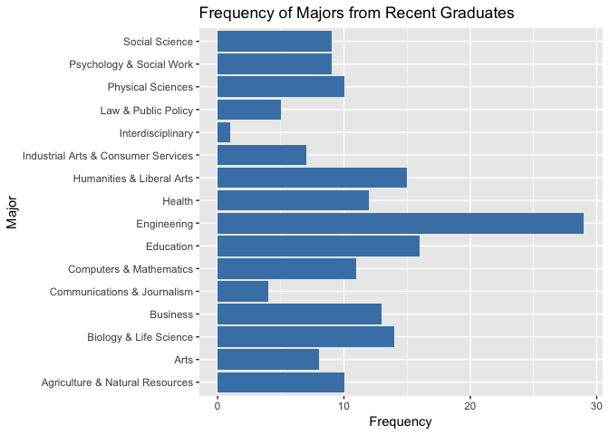

```r
library(ggplot2)
par(las=2)
majorcountfreq<-major_count$freq
plotcount<-ggplot(data=major_count, aes(x,majorcountfreq)) + xlab("Major") +  ylab("Frequency") + ggtitle("Frequency of Majors from Recent Graduates") + coord_flip() + geom_bar(stat="identity", fill = "Steelblue")
plotcount
```

4. Write the fivethirtyeight data to a csv file. Make sure that it does not have row labels.

```r
# Have the new .csv file pulled from fivethirtyeight placed into the Homework directory on the local comp.
setwd("~/Desktop/Kari/SMU /Doing Data Science/Homework")
# Write/Create a new csv file. Call it Major_Count and pull in the data from variable majori_count
write.csv(major_count, file = "Major_Count.csv", row.names=FALSE, na="")
```

## **Question 6**

### Codebook:

1. Start a new repository on GitHub for your SMU MSDS homework. On your local device, make sure there is a directory for Homework at the minimum; you are welcome to add whatever you would like to this repo in addition to your requirements here. Done
2. Create a README.md file which explains the purpose of the repository, the topics included, the sources for the material you post, and contact information in case of questions. Remember, the one in the root directory should be general. You are welcome to make short READMEs for each assignment individually in other folders. Done
3. In one (or more) of the nested directories, post your RMarkdown script, HTML file, and data from ‘fivethirtyeight.’ Make sure that in your README or elsewhere that you credit fivethirtyeight in some way. Done
4. In your RMarkdown script, please provide the link to this GitHub so the grader can see it. https://github.com/TheobaldK/MSDS-6306-Homework.git